# Assignment 3 - The free position facility location problem

Louis Fabrice Tshimanga

18 May 2019

## The Problem

In this assignment we will look at the **Facility Location Problem**. The problem can be described in general terms as follows:

We must decide the placement of a facility that distributes a certain good to a group of consumers that need it.

The placement must be chosen in order to **minimize** the total compound distance from the facility and the customers.

The following assumptions has to be taken into account:

1. The possible location for the facility is unknown, that is, the problem is to find the right spot to build it.
2. The facility building costs are fixed and independent from the position of the building site.

Notice that in this scenario there is one possible decision to make:

- where to build the facility, that is, find the position ($\chi$, $\upsilon$) that minimises the compound distance of the facility with respect to all custumers.

### Data

A file with the locations of the consumers can be found in the `Data` folder.

## Distance function

Given the position of the facility $f= (\chi, \upsilon)$ and of a consumer $p_i=(x_i, y_i)$ use the following formula to calculate the distance between them.

$$d(f,p_i) = log((\chi-x_i)^2+1) + log((\upsilon-y_i)^2+1)$$

## The assignment

1. Formulate the objective function to minimize for the described problem.  
   Answer:

$$F(f)=\sum_{p_i \in P} d(f,p_i) = \sum_{p_i \in P} log((\chi-x_i)^2+1) + log((\upsilon-y_i)^2+1)$$
$$with\ P =\{p_i \ \ in \ Data\}, \ 100 \ data points$$
$F(f)$ with 100 parameters $p_i$ is the function to be **minimized**, implemented in R as “Fulldistance”, where “distance” is $d(f,p_i)$. $F(f)$ is a scalar field of a 2D space. Its gradient is a 2D-vector field.

```r
distance <- function(f, x_i, y_i) {
  chi<-f[1]
  nu<-f[2]
  d = log((chi-x_i)^2+1) + log((nu-y_i)^2+1)
  return(d)
}

Fulldistance <- function(f, xs, ys) {
  D = 0
  if(length(xs)==length(ys)){
    for(i in 1:length(xs)){
      d = distance(f, xs[i], ys[i])
      D = D + d
    }#end of for-cycle; it gives the sum of all distances
    return(D)
  }#end of if-statement
}
```

Beware there’s the hidden code to load the data, it must be updated with the current location.

2. Express in analytical form the gradient for the objective to be minimized.  
   Answer:

$$\nabla d = \left[\ \frac{\partial d}{\partial \chi} \ \ \ \ \ \frac{\partial d}{\partial \nu} \ \right]
\\
\frac{\partial d(\chi,\nu,p_i)}{\partial \chi} = \frac{1}{((\chi-x_i)^2+1)}\cdot2(\chi-x_i)
\\
\frac{\partial d(\chi,\nu,p_i)}{\partial \nu} =
\frac{1}{((\nu-y_i)^2+1)}\cdot2(\nu-y_i)$$
Knowing that (given $D[]$ as the derivative operator)
$$D[log(function)]=\frac{1}{function}\cdot D[function]$$
Both the sum and the derivative operators are linear, hence the sum of derivatives and the derivative of the sums are the same mathematical entity.
Thus, at last
$$\nabla F(f=(\chi,\nu)) = \nabla\sum_{p_i \in P} d(f) = \sum_{p_i \in P} \nabla d(f)
\\
\nabla F(f) = \sum_{p_i \in P} \left[\ \frac{\partial d(f)}{\partial \chi} \ \ \ \ \ \frac{\partial d(f)}{\partial \nu} \ \right]=
\\
=\left[\sum_{i = 1}^{100}\frac{\partial d(\chi,\nu,p_i)}{\partial \chi}
\ \ \ \sum_{i = 1}^{100}\frac{\partial d(\chi,\nu,p_i)}{\partial \nu}\right]$$

```r
#this is specifically adapted to the study case
graddist <- function(f, x_i, y_i){ #gradient of distance(f, p_i)
  chi<-f[1]
  nu<-f[2]

  gd1 = 2*(chi-x_i)/((chi-x_i)^2+1)
  gd2 = 2*(nu-y_i)/((nu-y_i)^2+1)

  gd=c(gd1,gd2)
  return(gd)
}


GradFullDist <- function(f, xs, ys){ #gradient of FullDistance(f, set of all points)
  GFD = c(0,0)
  for(i in 1:length(xs)){
    GFD = GFD+graddist(f, xs[i], ys[i])
  } #end of for cycle, the gradient components of F are the sums of the
  #gradient components of d, as analytcally showed above
  return(GFD)
}
```

3. Implement the `Gradiend Descent method` and solve the problem with it.  
   Answer:  
   The Gradient Descent method finds the local optimum point of a differentiable function (the point with zero derivatives) “descending” the function in the direction suggested by its gradient, and with the sign depending on wether we’re seeking a minimum or a maximum. In this case, we’re looking for a minimization of the “Full Distance” function of any given point, so at every iteration we’d take a step in the opposite direction of the gradient (which itself points to the steepest ascent), following then the steepest descent. The “stepsize modulator” will be initially taken as an educated guess, and kept costant, but its size can be adapted to obtain a better, adaptive learning rate; the direction, instead, can change at any iteration, due to the shape of the function.

So, at iteration k+1, the candidate point (or position-vector) is
$$x_{k+1}=x_k-s\nabla F(x_k)$$
with learning rate (modulating the stepsize) equal to ‘$s$’. If either the gradient is zero, or the distance between consecutive candidates is small enough, or the iterations have reached the maximum allowed, we stop the search process.

```r
#bivariate-function implementation of the Gradient Descent Method, specific to the study case, with fixed learning rate
Function<-function(x){Fulldistance(x, Data$x, Data$y)}
Gradient<-function(x){GradFullDist(x, Data$x, Data$y)}

GDM <- function(starter, Function, Gradient, LR=0.01, max_iter=10000, tol=0.000000001) {
  step = LR
  iterations = 0

  normae<-function(v){return(sqrt(sum(v*v))) } #to check later if the difference between
  #candidates in consecutive iterations is small enough (see tol)

  for (i in 1:max_iter){
    gradient<-Gradient(starter)
    new_point = starter - step*gradient

    #updates
    starter = new_point
    iterations = iterations+1
    improvement = normae(step*gradient)/normae(new_point)

    if (improvement <= tol){
      break
    } #the function is "learning" too little at this point

  } #end of for cycle

  Result=list(OptimalPoint=starter, OptimalValue=Function(starter), Iterations=iterations)
  return(Result)
}
```

A better implementation of the gradient descent, using an adaptive learning rate, is quickly presented.
The difference in the new method consists in having
$$s_k \ s.t. \frac{\partial H(s_k)}{\partial s_k}=0
\\
e.g.: s_k= \underset{s_k}{\operatorname{argmin}} F(x_k-s_k\nabla F(x_k))$$
To execute this “nested optimization” one would need either a fixed analytical solution, or a trusted algorithm (e.g.: Newton’s Method, Bisection Method, etc.) to find at any iteration the s to best modulate the stepsize (which is a root, or zero, of some function).

As stated earlier, any such method will yield a local solution that may well depend on the starting point, so that it would be better to try our Gradient Descent function with a handful of starters after an inspection of the function

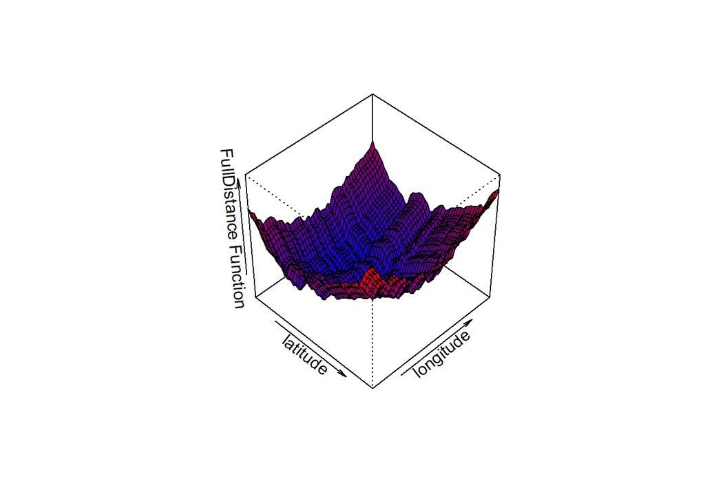

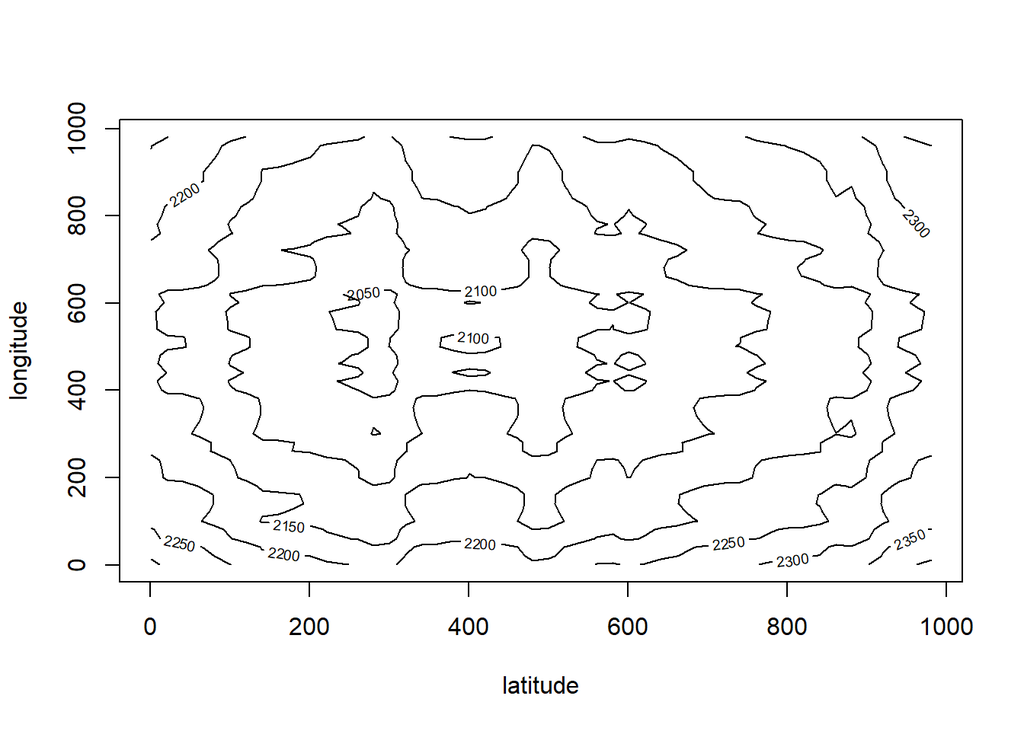

It seems likely that a global minumum would be found in a region of the area slightly off-center, near the contour line of level=$2050$. The search could then start from points $A(200,400)$, $B(300,400)$, $C(300,600)$, $D(200,600)$, executing the Gradient Descent Method with learning rate of $0.1$ [code present but hidden], and then starting again from the best of candidate points, with a new (smaller) learning rate.

```r
caseA
```

```
## $OptimalPoint
## [1] 200.8717 430.8702
##
## $OptimalValue
## [1] 2057.043
##
## $Iterations
## [1] 897
```

```r
caseB
```

```
## $OptimalPoint
## [1] 310.1627 430.8702
##
## $OptimalValue
## [1] 2004.964
##
## $Iterations
## [1] 896
```

```r
caseC
```

```
## $OptimalPoint
## [1] 310.1627 601.1187
##
## $OptimalValue
## [1] 2011.191
##
## $Iterations
## [1] 124
```

```r
caseD
```

```
## $OptimalPoint
## [1] 200.8717 601.1187
##
## $OptimalValue
## [1] 2063.269
##
## $Iterations
## [1] 71
```

Point $B$ seems the most promising starting point, yielding the minimal optimal point, so:

```r
newcaseB<-GDM(B, Function, Gradient, 0.01)
newcaseB
```

```
## $OptimalPoint
## [1] 310.1627 430.8702
##
## $OptimalValue
## [1] 2004.964
##
## $Iterations
## [1] 8796
```

With a messier contour outline, or in the absence of it, it might be convenient to sample randomly many starting points and then analize in an analogous way the results.

4. Solve the problem with a package provided by R (for instance, using the function `optimr` within the package `optimx`). Note that it is not required to use the `gradient descent` algorithm to solve the problem, other algorithms can be used as well.  
   Answer:

```r
#install.packages("optimx")
library("optimx")
#help(optimr)

par<-B #trying a known good candidate
fn<-function (x) {return(Fulldistance(x, Data$x, Data$y))} #adaptin to the optimr requirements

optimr(par, fn)
```

```
## $par
## [1] 310.1615 430.8689
##
## $value
## [1] 2004.964
##
## $counts
## function gradient
##       61       NA
##
## $convergence
## [1] 0
##
## $message
## NULL
```

The optimal location point is very close to the ones found from B with the GDM at different learning rates.

5. Implement the `Stochastic gradient descent` algorithm with mini-batches and use it to solve the problem.  
   Answer:  
   The Stochastic gradient descent is **stochastic** in the selection of addend functions that constitute the gradient. A new sample, mini-batch, is used to compute a faster approximation of the gradient, at each iteration step. The technique turns out useful when the addends and parameters are many, and might be quite off-target in simple problems with small mini-batches. A standard typical of machine learning approaches will be followed hereon, with only about a third ($34\%$) of the data points sampled at any iteration.

```r
set.seed(13) #a lucky number

#the implementation is specific to the functions and parameters of this study case
StochasticGDM <- function(starter, LR=0.01, max_iter=10000, tol=0.000000001, minibatchsize=34) {
  step = LR
  iterations = 0

  normae<-function(v){return(sqrt(sum(v*v))) }

  for (i in 1:max_iter){
    minibatch<-sample(length(Data$x), minibatchsize)
    gradient<-GradFullDist(starter,Data$x[minibatch],Data$y[minibatch])
    #it has been thus implemented the stochasticity, since we're sampling a mini-batch
    #to evaluate the gradient(s) of our function(s) (remember: grad F depends on grad d)
    new_point = starter - step*gradient
    #updates
    starter = new_point
    iterations = iterations+1
    improvement = normae(step*gradient)/normae(new_point)

    if (improvement <= tol){
      break
    }

  } #end of for cycle
  Result=list(OptimalPoint=starter, OptimalValue=Fulldistance(starter, Data$x, Data$y),Iterations=iterations)
  return(Result)
}

StochasticMinimum<-StochasticGDM(B, 0.005, 100000)
StochasticMinimum
```

```
## $OptimalPoint
## [1] 310.2068 430.7852
##
## $OptimalValue
## [1] 2004.971
##
## $Iterations
## [1] 1e+05
```

Once again the results are in the neighbourhood of point $(310,431)$, which confirms the consistency of the presented methods.